# Health spending divergence: fast-growing vs stagnating EU health systems

Between 2000 and 2023, EU health spending trajectories diverged dramatically. Newer members like Romania, Poland, and Malta more than doubled their real spending, while Southern European countries barely grew — Italy +21%, Greece +26%.

This notebook examines health spending across **all 27 EU member states** using three WHO datasets:

- `EU_health_spend.csv` — total health expenditure by financing type (2000–2023)
- `EU_spend_purpose.csv` — spending by purpose/function (2016–2023)
- `EU_US_lifeExp.csv` — life expectancy snapshots (2002, 2007, 2023)

Throughout, countries are grouped as **fast growers** (Malta, Ireland, Romania, Poland, Slovakia — red), **slow growers** (Italy, Greece, Portugal — blue), and **other EU** (grey) for context.

**Setup and data loading**

```python
import pandas as pd
import matplotlib.pyplot as plt
import matplotlib.ticker as mticker
import seaborn as sns
import numpy as np

sns.set_theme(style='whitegrid', palette='colorblind')
plt.rcParams['figure.figsize'] = (14, 6)
plt.rcParams['figure.dpi'] = 100

# Load data
spend = pd.read_csv('data/EU_health_spend.csv')
purpose = pd.read_csv('data/EU_spend_purpose.csv')
life = pd.read_csv('data/EU_US_lifeExp.csv')

# Harmonize Netherlands naming
spend['country_name'] = spend['country_name'].replace('Netherlands (Kingdom of the)', 'Netherlands')
purpose['country_name'] = purpose['country_name'].replace('Netherlands (Kingdom of the)', 'Netherlands')

# Reference groups
FAST_GROWERS = ['Malta', 'Ireland', 'Romania', 'Poland', 'Slovakia']
SLOW_GROWERS = ['Italy', 'Greece', 'Portugal']

def group_label(country):
    if country in FAST_GROWERS:
        return 'Fast growers'
    elif country in SLOW_GROWERS:
        return 'Slow growers'
    return 'Other EU'

def group_color(country):
    if country in FAST_GROWERS:
        return '#e74c3c'
    elif country in SLOW_GROWERS:
        return '#2980b9'
    return '#555555'

# Prepare CHE data (used throughout)
che = spend[spend['expenditure_type'] == 'Current Health Expenditure (CHE)'].copy()

# Compute total growth 2000-2023 for sorting
growth_00_23 = {}
for c in che['country_name'].unique():
    d = che[che['country_name'] == c]
    v0 = d[d['year'] == 2000]['value'].values
    v1 = d[d['year'] == 2023]['value'].values
    if len(v0) and len(v1):
        growth_00_23[c] = (v1[0] / v0[0] - 1) * 100

ALL_COUNTRIES = sorted(growth_00_23, key=growth_00_23.get, reverse=True)

# Small multiples layout
SM_NCOLS = 5
SM_NROWS = int(np.ceil(len(ALL_COUNTRIES) / SM_NCOLS))

print(f'Spend: {len(spend)} rows, Purpose: {len(purpose)} rows, Life exp: {len(life)} rows')
print(f'{len(ALL_COUNTRIES)} EU countries, sorted by total growth 2000-2023')
print(f'\nFast growers: {FAST_GROWERS}')
print(f'Slow growers: {SLOW_GROWERS}')
```

```
Spend: 2172 rows, Purpose: 1581 rows, Life exp: 67 rows
27 EU countries, sorted by total growth 2000-2023

Fast growers: ['Malta', 'Ireland', 'Romania', 'Poland', 'Slovakia']
Slow growers: ['Italy', 'Greece', 'Portugal']
```

## 1. The divergence: total health spending over time

How have EU countries’ spending trajectories diverged since 2000?

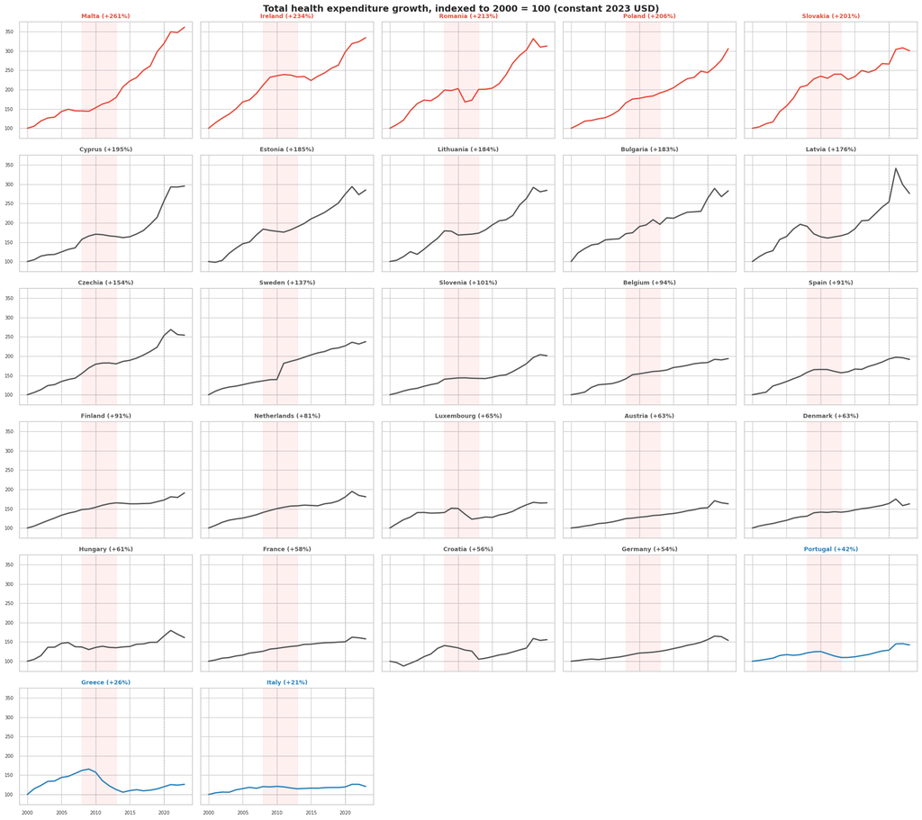

Figure 1: Total health expenditure growth indexed to 2000 for all EU countries, sorted by total growth. Red = fast growers, blue = slow growers.

```python
# Index to 2000 = 100 for all countries
che_idx = che[che['country_name'].isin(ALL_COUNTRIES)].copy()
base_2000 = che_idx[che_idx['year'] == 2000].set_index('country_name')['value']
che_idx = che_idx[che_idx['country_name'].isin(base_2000.index)]
che_idx['indexed'] = che_idx.apply(lambda r: r['value'] / base_2000[r['country_name']] * 100, axis=1)

fig, axes = plt.subplots(SM_NROWS, SM_NCOLS, figsize=(20, SM_NROWS * 3), sharex=True, sharey=True)

for i, country in enumerate(ALL_COUNTRIES):
    ax = axes.flat[i]
    d = che_idx[che_idx['country_name'] == country]
    color = group_color(country)
    ax.plot(d['year'], d['indexed'], color=color, linewidth=2)
    ax.axhline(100, color='grey', linestyle='--', alpha=0.3, linewidth=0.5)
    ax.axvspan(2008, 2013, alpha=0.06, color='red')
    ax.axvline(2020, color='grey', linestyle=':', alpha=0.3)
    growth_pct = growth_00_23.get(country, 0)
    ax.set_title(f'{country} ({growth_pct:+.0f}%)', fontsize=9, fontweight='bold', color=color)
    ax.tick_params(labelsize=7)

for j in range(len(ALL_COUNTRIES), SM_NROWS * SM_NCOLS):
    axes.flat[j].set_visible(False)

fig.suptitle('Total health expenditure growth, indexed to 2000 = 100 (constant 2023 USD)',
             fontsize=14, fontweight='bold')
plt.tight_layout()
plt.show()
```

## 2. Did the eurozone crisis cause the stagnation?

Southern Europe was hit hard by austerity after 2008. Let’s see how spending changed in distinct periods.

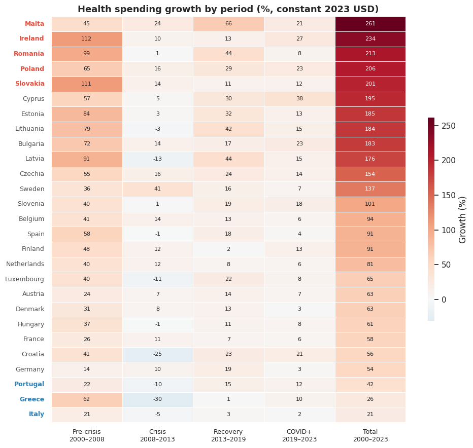

Figure 2: Health spending growth by period for all EU countries, sorted by total growth.

```python
periods = [
    ('Pre-crisis\n2000\u20132008', 2000, 2008),
    ('Crisis\n2008\u20132013', 2008, 2013),
    ('Recovery\n2013\u20132019', 2013, 2019),
    ('COVID+\n2019\u20132023', 2019, 2023),
]

che_pivot = che[che['country_name'].isin(ALL_COUNTRIES)].pivot(
    index='year', columns='country_name', values='value')

period_growth = []
for label, y_start, y_end in periods:
    for country in ALL_COUNTRIES:
        try:
            v_start = che_pivot.loc[y_start, country]
            v_end = che_pivot.loc[y_end, country]
            growth = (v_end / v_start - 1) * 100
        except KeyError:
            growth = np.nan
        period_growth.append({'period': label, 'country': country, 'growth': growth})

pg = pd.DataFrame(period_growth)

pg_wide = pg.pivot(index='country', columns='period', values='growth')
pg_wide = pg_wide[[p[0] for p in periods]]
pg_wide['Total\n2000\u20132023'] = pg_wide.index.map(lambda c: growth_00_23.get(c, np.nan))
pg_wide = pg_wide.reindex(ALL_COUNTRIES)

fig, ax = plt.subplots(figsize=(10, 9))
sns.heatmap(pg_wide, annot=True, fmt='.0f', cmap='RdBu_r', center=0,
            linewidths=0.4, linecolor='white', ax=ax, annot_kws={'size': 8},
            cbar_kws={'label': 'Growth (%)', 'shrink': 0.5, 'aspect': 30})
ax.set_title('Health spending growth by period (%, constant 2023 USD)',
             fontsize=13, fontweight='bold')
ax.set_ylabel('')
ax.set_xlabel('')
ax.tick_params(axis='y', labelsize=9)
ax.tick_params(axis='x', labelsize=9)

for i, label in enumerate(ax.get_yticklabels()):
    label.set_color(group_color(ALL_COUNTRIES[i]))
    label.set_fontweight('bold' if ALL_COUNTRIES[i] in FAST_GROWERS + SLOW_GROWERS else 'normal')

plt.tight_layout()
plt.show()
```

```python
pg_table = pg_wide.copy()
pg_table['group'] = pg_table.index.map(group_label)
pg_table.round(1)
```

Table 1: Growth rates by period for all EU countries

| period country | Pre-crisis\n2000–2008 | Crisis\n2008–2013 | Recovery\n2013–2019 | COVID+\n2019–2023 | Total\n2000–2023 | group |
| --- | --- | --- | --- | --- | --- | --- |
| Malta | 44.8 | 24.2 | 65.8 | 21.2 | 261.3 | Fast growers |
| Ireland | 111.9 | 9.8 | 13.1 | 27.0 | 234.1 | Fast growers |
| Romania | 98.8 | 0.8 | 43.8 | 8.4 | 212.6 | Fast growers |
| Poland | 65.5 | 15.6 | 29.4 | 23.5 | 205.8 | Fast growers |
| Slovakia | 110.9 | 13.8 | 11.4 | 12.4 | 200.5 | Fast growers |
| Cyprus | 57.5 | 4.6 | 30.1 | 37.8 | 195.2 | Other EU |
| Estonia | 83.9 | 3.3 | 32.2 | 13.5 | 185.0 | Other EU |
| Lithuania | 79.4 | -3.4 | 42.0 | 15.4 | 184.2 | Other EU |
| Bulgaria | 71.9 | 14.1 | 17.2 | 23.0 | 182.8 | Other EU |
| Latvia | 91.1 | -12.8 | 44.5 | 14.6 | 176.1 | Other EU |
| Czechia | 55.2 | 16.0 | 24.0 | 14.0 | 154.2 | Other EU |
| Sweden | 36.0 | 40.5 | 15.8 | 7.3 | 137.4 | Other EU |
| Slovenia | 40.3 | 1.4 | 19.4 | 18.4 | 101.0 | Other EU |
| Belgium | 41.1 | 14.4 | 13.0 | 6.2 | 93.6 | Other EU |
| Spain | 57.9 | -0.7 | 17.8 | 3.6 | 91.5 | Other EU |
| Finland | 47.8 | 11.7 | 1.8 | 13.5 | 90.7 | Other EU |
| Netherlands | 40.5 | 12.0 | 8.1 | 6.2 | 80.7 | Other EU |
| Luxembourg | 40.1 | -10.6 | 21.7 | 8.3 | 65.1 | Other EU |
| Austria | 24.3 | 7.3 | 13.5 | 7.5 | 62.7 | Other EU |
| Denmark | 30.6 | 7.8 | 12.6 | 2.5 | 62.5 | Other EU |
| Hungary | 36.8 | -1.3 | 10.5 | 8.1 | 61.3 | Other EU |
| France | 25.9 | 11.0 | 7.0 | 5.6 | 57.9 | Other EU |
| Croatia | 40.6 | -25.2 | 22.9 | 20.5 | 55.8 | Other EU |
| Germany | 14.1 | 10.2 | 18.5 | 3.3 | 54.0 | Other EU |
| Portugal | 21.6 | -9.8 | 15.5 | 12.2 | 42.1 | Slow growers |
| Greece | 62.2 | -30.5 | 1.4 | 10.4 | 26.3 | Slow growers |
| Italy | 20.5 | -4.8 | 3.0 | 2.2 | 20.8 | Slow growers |

## 3. Government vs private spending share over time

How has the split between government and private health spending evolved? Each panel shows the proportion stacked to 100%.

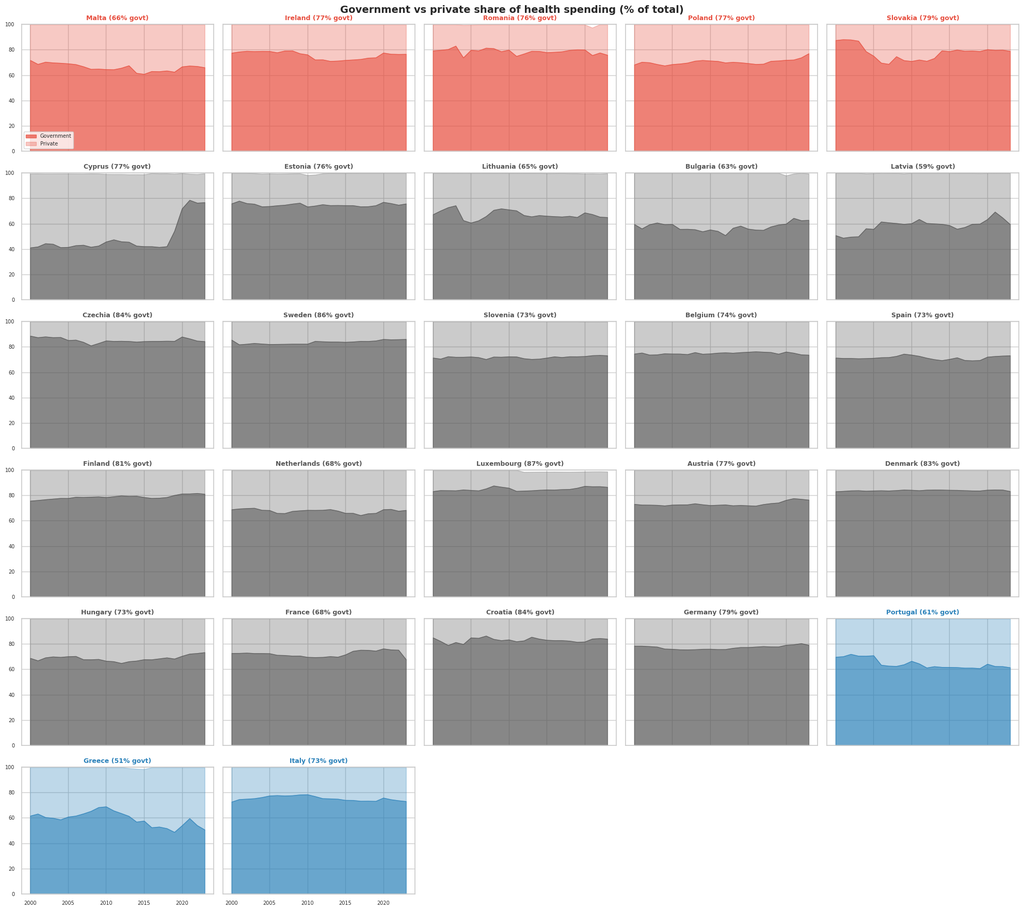

Figure 3: Government vs private health spending shares over time, normalized to 100%.

```python
pvt = spend[spend['expenditure_type'] == 'Domestic Private Health Expenditure (PVT-D)'].copy()
pvt = pvt.rename(columns={'value': 'pvt'})[['country_name', 'year', 'pvt']]
stacked = merged.merge(pvt, on=['country_name', 'year'])
stacked['govt_pct'] = stacked['gghe'] / stacked['che'] * 100
stacked['pvt_pct'] = stacked['pvt'] / stacked['che'] * 100

fig, axes = plt.subplots(SM_NROWS, SM_NCOLS, figsize=(20, SM_NROWS * 3), sharex=True, sharey=True)

for i, country in enumerate(ALL_COUNTRIES):
    ax = axes.flat[i]
    d = stacked[stacked['country_name'] == country].sort_values('year')
    color = group_color(country)
    ax.fill_between(d['year'], 0, d['govt_pct'], alpha=0.7, label='Government', color=color)
    ax.fill_between(d['year'], d['govt_pct'], d['govt_pct'] + d['pvt_pct'], alpha=0.3, label='Private', color=color)
    ax.set_ylim(0, 100)
    gs_2023 = d[d['year'] == 2023]['govt_pct'].values
    gs_label = f' ({gs_2023[0]:.0f}% govt)' if len(gs_2023) else ''
    ax.set_title(f'{country}{gs_label}', fontsize=9, fontweight='bold', color=color)
    ax.tick_params(labelsize=7)
    if i == 0:
        ax.legend(fontsize=7, loc='lower left')

for j in range(len(ALL_COUNTRIES), SM_NROWS * SM_NCOLS):
    axes.flat[j].set_visible(False)

fig.suptitle('Government vs private share of health spending (% of total)',
             fontsize=14, fontweight='bold')
plt.tight_layout()
plt.show()
```